# Johns Hopkins University - Practical Machine Learning Specialization

Predicting the manner in which people did exercises based on machine learning algorithms

Herwin Pozzobon Silva

26 de setembro de 2015

# Summary

The goal of this project is to predict the manner in which people did exercises based on data collected from http://groupware.les.inf.puc-rio.br/har. We will focus on the classification of each row of the testing set trying to define if it corresponds to a well done exercise (classe A) or to an incorrectly done (classe B to E).

# Preparation

### Cleaning the global environment

```r
rm(list=ls(envir = .GlobalEnv), envir = .GlobalEnv)
gc()
```

```
##          used (Mb) gc trigger (Mb) max used (Mb)
## Ncells 308527 16.5     592000 31.7   359603 19.3
## Vcells 506267  3.9    1023718  7.9   786282  6.0
```

### Loading packages

```r
pkg   <- c("diagram", "caret", "dplyr", "ggplot2")
for (i in pkg) {
   if(i %in% rownames(installed.packages()) == FALSE) install.packages(i, dependencies=TRUE)
   library(i, character.only = TRUE)
}
```

### Choosing and going to the project directory

```r
wdDir <- dirname(choose.dir(caption="Select the project folder:"))
setwd(paste(wdDir, "\\PeerAssessment", sep = ""))
```

# Planning the Project

### Framework proposed by the course

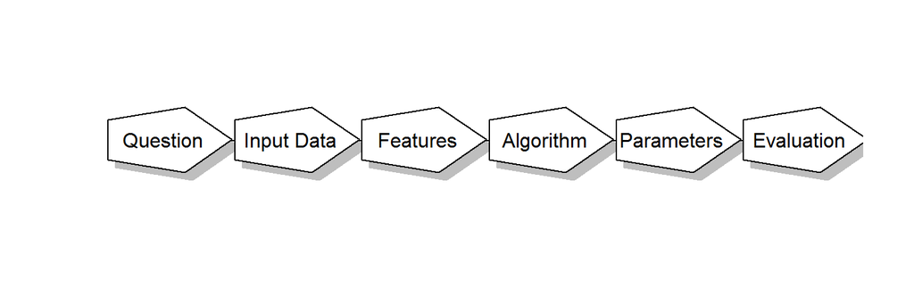

# Executing the project

## Question

As mentioned in the course assignement page, “the goal of the project is to predict the manner in which they did the exercise” and this must be made via the “classe” variable in the training set.

We may establish that the question to answer may be: “**is it possible to predict if people did exercises correctly based on previous classification done by experts ?**”

## Input data

We assume the premise that the **training set** provided by the course web site is relevant, done by experts and the right data to use in this kind of prediction and that the **test set** was collected and organized according to that structure and criteria.

### Downloading and reading files

```r
url            <- "https://d396qusza40orc.cloudfront.net/predmachlearn/"
training.file  <- "pml-training.csv"
testing.file   <- "pml-testing.csv"

if (!file.exists(training.file)) download.file(paste(url, training.file, sep=""), destfile=training.file)
if (!file.exists(testing.file))  download.file(paste(url, testing.file,  sep=""), destfile=testing.file)

training <- read.csv(training.file, header = TRUE, sep=",")
testing  <- read.csv(testing.file,  header = TRUE, sep=",")
```

### Checking data sets

#### Checking the colum names

Creating a logical vector to check if all columns have the same name (colCheck). As we can see, 159 columns have the same name (just one, the “classe” column is different):

```r
colCheck <- names(training)[1:length(training)] != names(testing)[1:length(testing)]
names(training)[colCheck == TRUE]       # the different columns in the training set
```

```
## [1] "classe"
```

```r
names(testing) [colCheck == TRUE]       # the different columns in the testing set
```

```
## [1] "problem_id"
```

#### Removing columns without valid data in both sets

```r
training    <- training[,(colSums(is.na(training)) == 0)]
testing     <- testing[,(colSums(is.na(testing)) == 0)]
training    <- training[-3:-7]
testing     <- testing [-3:-7]
```

## Features

After the cleaning operation above, the data sets results with different number of columns. So, we must use the remaining columns of the testing data set in our model as we see below:

```r
dim(training)[2]; dim(testing)[2] # number of columns in both data sets
```

```
## [1] 88
## [1] 55
```

```r
names(testing)[3:dim(testing)[2]] # the columns to be used in the model
```

```
##  [1] "roll_belt"            "pitch_belt"           "yaw_belt"
##  [4] "total_accel_belt"     "gyros_belt_x"         "gyros_belt_y"
##  [7] "gyros_belt_z"         "accel_belt_x"         "accel_belt_y"
## [10] "accel_belt_z"         "magnet_belt_x"        "magnet_belt_y"
## [13] "magnet_belt_z"        "roll_arm"             "pitch_arm"
## [16] "yaw_arm"              "total_accel_arm"      "gyros_arm_x"
## [19] "gyros_arm_y"          "gyros_arm_z"          "accel_arm_x"
## [22] "accel_arm_y"          "accel_arm_z"          "magnet_arm_x"
## [25] "magnet_arm_y"         "magnet_arm_z"         "roll_dumbbell"
## [28] "pitch_dumbbell"       "yaw_dumbbell"         "total_accel_dumbbell"
## [31] "gyros_dumbbell_x"     "gyros_dumbbell_y"     "gyros_dumbbell_z"
## [34] "accel_dumbbell_x"     "accel_dumbbell_y"     "accel_dumbbell_z"
## [37] "magnet_dumbbell_x"    "magnet_dumbbell_y"    "magnet_dumbbell_z"
## [40] "roll_forearm"         "pitch_forearm"        "yaw_forearm"
## [43] "total_accel_forearm"  "gyros_forearm_x"      "gyros_forearm_y"
## [46] "gyros_forearm_z"      "accel_forearm_x"      "accel_forearm_y"
## [49] "accel_forearm_z"      "magnet_forearm_x"     "magnet_forearm_y"
## [52] "magnet_forearm_z"     "problem_id"
```